# Bay Wheels May 2020 Trip Data Analysis

## Preliminary Wrangling

The data under analysis is the Bay Wheels trip history data. Bay wheel trip provides bike share service as a new transportation option in Bay area, USA. They have deployed a number of stations and bikes throughout San Francisco, the East Bay, and San Jose. Besides the traditional docked bikes, Bay Wheels introduces ebikes during 2019 November. A rider needs to download an APP called Lyft and scan the QR code on the bike when start using it and then return it back to one of the stations when the trip ends. Rider can pay by monthly/yearly membership fee or per ride. This report focuses on the data gathered during May 2020.

```python
# import all packages and set plots to be embedded inline
import numpy as np
import pandas as pd
import matplotlib.pyplot as plt
import seaborn as sb
from pandas.api.types import CategoricalDtype

%matplotlib inline
```

```python
# load the dataset
df = pd.read_csv('202005-baywheels-tripdata.csv')
```

```python
print(df.shape)
print(df.info())
df.head()
```

```
(138251, 14)
<class 'pandas.core.frame.DataFrame'>
RangeIndex: 138251 entries, 0 to 138250
Data columns (total 14 columns):
 #   Column              Non-Null Count   Dtype
---  ------              --------------   -----
 0   ride_id             138251 non-null  object
 1   rideable_type       138251 non-null  object
 2   started_at          138251 non-null  object
 3   ended_at            138251 non-null  object
 4   start_station_name  87315 non-null   object
 5   start_station_id    87315 non-null   float64
 6   end_station_name    84779 non-null   object
 7   end_station_id      84779 non-null   float64
 8   start_lat           138251 non-null  float64
 9   start_lng           138251 non-null  float64
 10  end_lat             138027 non-null  float64
 11  end_lng             138027 non-null  float64
 12  member_casual       138251 non-null  object
 13  is_equity           138251 non-null  bool
dtypes: bool(1), float64(6), object(7)
memory usage: 13.8+ MB
None
```

|  | ride_id | rideable_type | started_at | ended_at | start_station_name | start_station_id | end_station_name | end_station_id | start_lat | start_lng | end_lat | end_lng | member_casual | is_equity |
| --- | --- | --- | --- | --- | --- | --- | --- | --- | --- | --- | --- | --- | --- | --- |
| 0 | BA4B4D93677877E8 | electric_bike | 2020-05-18 22:16:06 | 2020-05-18 22:28:20 | NaN | NaN | NaN | NaN | 37.3443 | -121.9218 | 37.3443 | -121.9217 | casual | False |
| 1 | 92634E825C7303CC | electric_bike | 2020-05-19 16:57:35 | 2020-05-19 17:29:56 | NaN | NaN | NaN | NaN | 37.7286 | -122.4921 | 37.7154 | -122.4854 | casual | False |
| 2 | 1FCDD14C62521CC1 | electric_bike | 2020-05-18 20:08:14 | 2020-05-18 20:14:25 | NaN | NaN | Webster St at Clay St | 492.0 | 37.7919 | -122.4174 | 37.7906 | -122.4325 | casual | False |
| 3 | 3A5CEC684CA9FA18 | electric_bike | 2020-05-19 14:05:08 | 2020-05-19 14:14:16 | NaN | NaN | NaN | NaN | 37.7557 | -122.4165 | 37.7681 | -122.4266 | casual | False |
| 4 | 1FF95A9C2D1ED7F8 | electric_bike | 2020-05-10 17:45:54 | 2020-05-10 18:29:29 | Pier 1/2 at The Embarcadero | 12.0 | NaN | NaN | 37.7964 | -122.3946 | 37.7780 | -122.4144 | casual | False |

The dataframe has 14 columns and 138251 rows. Some of the columns, such as start_station_name, start_station_id, end_station_name, end_station_id, end_lat and end_lng, have null values.

```python
df.describe()
```

|  | start_station_id | end_station_id | start_lat | start_lng | end_lat | end_lng |
| --- | --- | --- | --- | --- | --- | --- |
| count | 87315.000000 | 84779.000000 | 138251.000000 | 138251.000000 | 138027.000000 | 138027.000000 |
| mean | 227.397022 | 226.186567 | 37.722310 | -122.343617 | 37.722268 | -122.344021 |
| std | 170.232761 | 170.207720 | 0.151435 | 0.182993 | 0.151488 | 0.183225 |
| min | 3.000000 | 3.000000 | 37.239200 | -122.514300 | 37.004600 | -122.559000 |
| 25% | 74.000000 | 74.000000 | 37.760100 | -122.433700 | 37.760000 | -122.433800 |
| 50% | 177.000000 | 171.000000 | 37.773500 | -122.413200 | 37.773500 | -122.413200 |
| 75% | 386.000000 | 386.000000 | 37.787300 | -122.390400 | 37.787400 | -122.390600 |
| max | 521.000000 | 521.000000 | 37.880200 | -121.774600 | 37.962100 | -121.560600 |

```python
df.sample(10)
```

|  | ride_id | rideable_type | started_at | ended_at | start_station_name | start_station_id | end_station_name | end_station_id | start_lat | start_lng | end_lat | end_lng | member_casual | is_equity |
| --- | --- | --- | --- | --- | --- | --- | --- | --- | --- | --- | --- | --- | --- | --- |
| 117784 | 4F85851D5EA674E7 | electric_bike | 2020-05-22 10:45:09 | 2020-05-22 10:50:37 | NaN | NaN | NaN | NaN | 37.7808 | -122.4762 | 37.7735 | -122.4788 | casual | False |
| 131432 | A8E22F2B0FE70E0B | electric_bike | 2020-05-24 07:05:22 | 2020-05-24 08:29:23 | Brannan St at 7th St | 482.0 | Brannan St at 7th St | 482.0 | 37.7727 | -122.4036 | 37.7727 | -122.4036 | casual | False |
| 94941 | 0C56B4B6C3650593 | electric_bike | 2020-05-31 18:44:13 | 2020-05-31 18:56:10 | Clara St at 4th St | 47.0 | NaN | NaN | 37.7809 | -122.4006 | 37.7771 | -122.4157 | casual | False |
| 93292 | 89CCAA9E838DD2FE | electric_bike | 2020-05-26 17:13:09 | 2020-05-26 17:17:01 | NaN | NaN | NaN | NaN | 37.7587 | -122.4187 | 37.7624 | -122.4194 | member | False |
| 130602 | 935A076503D8E99B | electric_bike | 2020-05-10 13:46:21 | 2020-05-10 13:59:16 | Civic Center/UN Plaza BART Station (Market St ... | 44.0 | Mission Dolores Park | 120.0 | 37.7813 | -122.4116 | 37.7614 | -122.4266 | casual | False |
| 65906 | 0C269F78A70F01DB | docked_bike | 2020-05-11 07:56:12 | 2020-05-11 08:30:07 | Cesar Chavez St at Dolores St | 140.0 | Cesar Chavez St at Dolores St | 140.0 | 37.7479 | -122.4250 | 37.7479 | -122.4250 | casual | False |
| 136678 | 7E8662A70D19D4DB | electric_bike | 2020-05-30 13:55:27 | 2020-05-30 14:24:26 | Jones St at Post St | 370.0 | Sanchez St at 17th St | 106.0 | 37.7873 | -122.4134 | 37.7633 | -122.4307 | casual | False |
| 58719 | F58397018378B746 | docked_bike | 2020-05-16 14:07:55 | 2020-05-16 15:27:24 | Telegraph Ave at Ashby Ave | 248.0 | Lakeside Dr at 14th St | 186.0 | 37.8560 | -122.2598 | 37.8013 | -122.2626 | member | False |
| 25631 | 5841420EC7DE38A1 | docked_bike | 2020-05-08 16:16:57 | 2020-05-08 16:24:30 | 17th St at Valencia St | 109.0 | Valencia St at 21st St | 127.0 | 37.7633 | -122.4219 | 37.7567 | -122.4210 | member | False |
| 100248 | 3762F9A6DE0004EC | electric_bike | 2020-05-26 11:18:19 | 2020-05-26 11:24:18 | 14th Ave at Geary Blvd | 474.0 | 7th Ave at Cabrillo St | 454.0 | 37.7805 | -122.4728 | 37.7752 | -122.4650 | casual | False |

```python
sum(df.duplicated())
```

```
0
```

There is no duplicated rows in the data.

```python
df.isnull().sum()
```

```
ride_id                   0
rideable_type             0
started_at                0
ended_at                  0
start_station_name    50936
start_station_id      50936
end_station_name      53472
end_station_id        53472
start_lat                 0
start_lng                 0
end_lat                 224
end_lng                 224
member_casual             0
is_equity                 0
dtype: int64
```

```python
print(df['member_casual'].value_counts())
print(df['rideable_type'].value_counts())
```

```
casual    84519
member    53732
Name: member_casual, dtype: int64
electric_bike    94251
docked_bike      44000
Name: rideable_type, dtype: int64
```

### Assessment

- Null values for the following columns: start_station_name, start_station_id, end_station_name, end_station_id, end_lat, end_lng
- start_station_id and end_station_id column data type is float rather than object
- started_at and ended_at column data type is object rather than datetime
- member_casual and rideable_type column data type is object rather than category
- the ended_at time is earlier than started_at time in some rows
- The end time is beyond the start time for some rows
- In some rows, the start_lat / start_lng and end_lat / end_lng remain the same with less than 10s using time. This indicates the user didn't ride the bike and stopped using the service after a very short time.

### Cleaning

```python
# copy the dataframe
df_clean = df.copy()
```

#### Define

Remove the rows if any of the following columns contains null values: start_station_name, start_station_id, end_station_name, end_station_id, end_lat, end_lng

#### Code

```python
# remove rows with null value
columns = ['start_station_name', 'start_station_id', 'end_station_name', 'end_station_id', 'end_lat', 'end_lng']
for col in columns:
    df_clean = df_clean[df_clean[col].isnull() == False]
```

#### Test

```python
df_clean.isnull().sum()
```

```
ride_id               0
rideable_type         0
started_at            0
ended_at              0
start_station_name    0
start_station_id      0
end_station_name      0
end_station_id        0
start_lat             0
start_lng             0
end_lat               0
end_lng               0
member_casual         0
is_equity             0
dtype: int64
```

#### Define

Change data types of start_station_id, end_station_id started_at from float to object. Change data type of started_at and ended_at columns from object to datetime.

#### Code

```python
# change start_station_id and end_station_id column dtype to object
df_clean['start_station_id'] = df['start_station_id'].astype(str)
df_clean['end_station_id'] = df['end_station_id'].astype(str)

# change started_at and ended_at column dtype to datetime
df_clean['started_at'] = pd.to_datetime(df_clean['started_at'])
df_clean['ended_at'] = pd.to_datetime(df_clean['ended_at'])
```

#### Test

```python
df_clean.info()
```

```
<class 'pandas.core.frame.DataFrame'>
Int64Index: 70895 entries, 8 to 138246
Data columns (total 14 columns):
 #   Column              Non-Null Count  Dtype
---  ------              --------------  -----
 0   ride_id             70895 non-null  object
 1   rideable_type       70895 non-null  object
 2   started_at          70895 non-null  datetime64[ns]
 3   ended_at            70895 non-null  datetime64[ns]
 4   start_station_name  70895 non-null  object
 5   start_station_id    70895 non-null  object
 6   end_station_name    70895 non-null  object
 7   end_station_id      70895 non-null  object
 8   start_lat           70895 non-null  float64
 9   start_lng           70895 non-null  float64
 10  end_lat             70895 non-null  float64
 11  end_lng             70895 non-null  float64
 12  member_casual       70895 non-null  object
 13  is_equity           70895 non-null  bool
dtypes: bool(1), datetime64[ns](2), float64(4), object(7)
memory usage: 7.6+ MB
```

#### Define

```python
# change rideable_type column data type to category
df_clean['rideable_type'] = df_clean['rideable_type'].astype(CategoricalDtype(categories=['electric_bike', 'docked_bike']))

# change member_casual column data type to category
df_clean['member_casual'] = df_clean['member_casual'].astype(CategoricalDtype(categories=['member', 'casual']))
```

#### Test

```python
df_clean.info()
```

```
<class 'pandas.core.frame.DataFrame'>
Int64Index: 70895 entries, 8 to 138246
Data columns (total 14 columns):
 #   Column              Non-Null Count  Dtype
---  ------              --------------  -----
 0   ride_id             70895 non-null  object
 1   rideable_type       70895 non-null  category
 2   started_at          70895 non-null  datetime64[ns]
 3   ended_at            70895 non-null  datetime64[ns]
 4   start_station_name  70895 non-null  object
 5   start_station_id    70895 non-null  object
 6   end_station_name    70895 non-null  object
 7   end_station_id      70895 non-null  object
 8   start_lat           70895 non-null  float64
 9   start_lng           70895 non-null  float64
 10  end_lat             70895 non-null  float64
 11  end_lng             70895 non-null  float64
 12  member_casual       70895 non-null  category
 13  is_equity           70895 non-null  bool
dtypes: bool(1), category(2), datetime64[ns](2), float64(4), object(5)
memory usage: 6.7+ MB
```

#### Define

Extract the weekday name and start time hour from started_at column and use its value to create two new columns. Extract the end weekday name and end hour from ended_at column.

#### Code

```python
# extract the weekday name from started_at column and use its value to create a new column called start_weekday_name
df_clean['start_weekday_name'] = df_clean['started_at'].dt.strftime('%a')

# change start_weekday_name column data type to category
weekday_name_categories = CategoricalDtype(categories=['Sun', 'Mon', 'Tue', 'Wed', 'Thu', 'Fri', 'Sat'],
                                          ordered=True)
df_clean['start_weekday_name'] = df_clean['start_weekday_name'].astype(weekday_name_categories)
```

```python
# extract start hour and create a new column called start_hour
df_clean['start_hour'] = df_clean['started_at'].dt.hour
```

```python
# extract the weekday name from ended_at column and use its value to create a new column called end_weekday_name
df_clean['end_weekday_name'] = df_clean['ended_at'].dt.strftime('%a')

# change end_weekday_name column data type to category
df_clean['end_weekday_name'] = df_clean['end_weekday_name'].astype(weekday_name_categories)
```

```python
# extract end hour and create a new column called end_hour
df_clean['end_hour'] = df_clean['ended_at'].dt.hour
```

#### Test

```python
df_clean.info()
```

```
<class 'pandas.core.frame.DataFrame'>
Int64Index: 70895 entries, 8 to 138246
Data columns (total 18 columns):
 #   Column              Non-Null Count  Dtype
---  ------              --------------  -----
 0   ride_id             70895 non-null  object
 1   rideable_type       70895 non-null  category
 2   started_at          70895 non-null  datetime64[ns]
 3   ended_at            70895 non-null  datetime64[ns]
 4   start_station_name  70895 non-null  object
 5   start_station_id    70895 non-null  object
 6   end_station_name    70895 non-null  object
 7   end_station_id      70895 non-null  object
 8   start_lat           70895 non-null  float64
 9   start_lng           70895 non-null  float64
 10  end_lat             70895 non-null  float64
 11  end_lng             70895 non-null  float64
 12  member_casual       70895 non-null  category
 13  is_equity           70895 non-null  bool
 14  start_weekday_name  70895 non-null  category
 15  start_hour          70895 non-null  int64
 16  end_weekday_name    70895 non-null  category
 17  end_hour            70895 non-null  int64
dtypes: bool(1), category(4), datetime64[ns](2), float64(4), int64(2), object(5)
memory usage: 7.9+ MB
```

```python
df_clean.info()
```

```
<class 'pandas.core.frame.DataFrame'>
Int64Index: 70895 entries, 8 to 138246
Data columns (total 18 columns):
 #   Column              Non-Null Count  Dtype
---  ------              --------------  -----
 0   ride_id             70895 non-null  object
 1   rideable_type       70895 non-null  category
 2   started_at          70895 non-null  datetime64[ns]
 3   ended_at            70895 non-null  datetime64[ns]
 4   start_station_name  70895 non-null  object
 5   start_station_id    70895 non-null  object
 6   end_station_name    70895 non-null  object
 7   end_station_id      70895 non-null  object
 8   start_lat           70895 non-null  float64
 9   start_lng           70895 non-null  float64
 10  end_lat             70895 non-null  float64
 11  end_lng             70895 non-null  float64
 12  member_casual       70895 non-null  category
 13  is_equity           70895 non-null  bool
 14  start_weekday_name  70895 non-null  category
 15  start_hour          70895 non-null  int64
 16  end_weekday_name    70895 non-null  category
 17  end_hour            70895 non-null  int64
dtypes: bool(1), category(4), datetime64[ns](2), float64(4), int64(2), object(5)
memory usage: 7.9+ MB
```

#### Define

Subtract the 'started_at' value from the 'ended_at' value to get the duration of ride. Use it to create a new column called duration.

#### Code

```python
# use start and end time to create a new column called duration
df_clean['duration'] = df_clean['ended_at'] - df_clean['started_at']

# change duration value to minutes
df_clean['duration'] = df_clean['duration'] / np.timedelta64(1, 's')

# round the value by changing data type to integer
df_clean['duration'] = df_clean['duration'].astype(int)
```

#### Test

```python
df_clean.duration.value_counts()
```

```
444      78
409      74
3        72
420      70
456      66
         ..
5233      1
5776      1
69760     1
7761      1
9698      1
Name: duration, Length: 7053, dtype: int64
```

```python
df_clean.info()
```

```
<class 'pandas.core.frame.DataFrame'>
Int64Index: 70895 entries, 8 to 138246
Data columns (total 19 columns):
 #   Column              Non-Null Count  Dtype
---  ------              --------------  -----
 0   ride_id             70895 non-null  object
 1   rideable_type       70895 non-null  category
 2   started_at          70895 non-null  datetime64[ns]
 3   ended_at            70895 non-null  datetime64[ns]
 4   start_station_name  70895 non-null  object
 5   start_station_id    70895 non-null  object
 6   end_station_name    70895 non-null  object
 7   end_station_id      70895 non-null  object
 8   start_lat           70895 non-null  float64
 9   start_lng           70895 non-null  float64
 10  end_lat             70895 non-null  float64
 11  end_lng             70895 non-null  float64
 12  member_casual       70895 non-null  category
 13  is_equity           70895 non-null  bool
 14  start_weekday_name  70895 non-null  category
 15  start_hour          70895 non-null  int64
 16  end_weekday_name    70895 non-null  category
 17  end_hour            70895 non-null  int64
 18  duration            70895 non-null  int64
dtypes: bool(1), category(4), datetime64[ns](2), float64(4), int64(3), object(5)
memory usage: 8.5+ MB
```

#### Define

Remove rows where duration value is less than 0. These are the rows where ended_at time is earlier than started_at time.

#### Code

```python
df_clean = df_clean.query('duration > 0')
```

#### Test

```python
df_clean.duration.describe()
```

```
count    7.067900e+04
mean     2.019052e+03
std      2.273507e+04
min      1.000000e+00
25%      4.730000e+02
50%      8.870000e+02
75%      1.679000e+03
max      2.061015e+06
Name: duration, dtype: float64
```

#### Define

Use the start latitude / longitude and end latitude / longitude to calculate the distance a user travels.

#### Code

```python
# calculate the circle distance between two points on the earth using latitude and longitude value
def calculate_distance(lon1, lat1, lon2, lat2):
    lon1, lat1, lon2, lat2 = map(np.radians, [lon1, lat1, lon2, lat2])

    dlon = lon2 - lon1
    dlat = lat2 - lat1

    a = np.sin(dlat/2.0)**2 + np.cos(lat1) * np.cos(lat2) * np.sin(dlon/2.0)**2

    c = 2 * np.arcsin(np.sqrt(a))
    km = 6367 * c
    return km
```

```python
# calculate the circle distance between the start point and end point and use its value to create a new column called distance
df_clean['distance'] = calculate_distance(df_clean['start_lat'], df_clean['start_lng'], df_clean['end_lat'], df_clean['end_lng'])

# round to two digits after decimal
df_clean['distance'] = df_clean['distance'].round(2);
```

#### Test

```python
df_clean.info()
```

```
<class 'pandas.core.frame.DataFrame'>
Int64Index: 70679 entries, 8 to 138246
Data columns (total 20 columns):
 #   Column              Non-Null Count  Dtype
---  ------              --------------  -----
 0   ride_id             70679 non-null  object
 1   rideable_type       70679 non-null  category
 2   started_at          70679 non-null  datetime64[ns]
 3   ended_at            70679 non-null  datetime64[ns]
 4   start_station_name  70679 non-null  object
 5   start_station_id    70679 non-null  object
 6   end_station_name    70679 non-null  object
 7   end_station_id      70679 non-null  object
 8   start_lat           70679 non-null  float64
 9   start_lng           70679 non-null  float64
 10  end_lat             70679 non-null  float64
 11  end_lng             70679 non-null  float64
 12  member_casual       70679 non-null  category
 13  is_equity           70679 non-null  bool
 14  start_weekday_name  70679 non-null  category
 15  start_hour          70679 non-null  int64
 16  end_weekday_name    70679 non-null  category
 17  end_hour            70679 non-null  int64
 18  duration            70679 non-null  int64
 19  distance            70679 non-null  float64
dtypes: bool(1), category(4), datetime64[ns](2), float64(5), int64(3), object(5)
memory usage: 9.0+ MB
```

```python
df_clean.sample(5)
```

|  | ride_id | rideable_type | started_at | ended_at | start_station_name | start_station_id | end_station_name | end_station_id | start_lat | start_lng | end_lat | end_lng | member_casual | is_equity | start_weekday_name | start_hour | end_weekday_name | end_hour | duration | distance |
| --- | --- | --- | --- | --- | --- | --- | --- | --- | --- | --- | --- | --- | --- | --- | --- | --- | --- | --- | --- | --- |
| 68097 | C319D318026DFB02 | docked_bike | 2020-05-28 18:41:01 | 2020-05-28 18:58:19 | Pierce St at Haight St | 73.0 | Jackson Playground | 115.0 | 37.7718 | -122.4337 | 37.7650 | -122.3988 | casual | False | Thu | 18 | Thu | 18 | 1038 | 3.90 |
| 51569 | 077C14A410B9CF60 | electric_bike | 2020-05-10 23:55:17 | 2020-05-11 00:06:52 | Garfield Square (25th St at Harrison St) | 139.0 | Sanchez St at 15th St | 95.0 | 37.7510 | -122.4121 | 37.7662 | -122.4311 | member | False | Sun | 23 | Mon | 0 | 695 | 2.30 |
| 7653 | 0122EB9F9C1CA86B | electric_bike | 2020-05-23 18:56:49 | 2020-05-23 19:24:34 | Bay St at Fillmore St | 399.0 | Mission Dolores Park | 120.0 | 37.8027 | -122.4360 | 37.7614 | -122.4265 | casual | False | Sat | 18 | Sat | 19 | 1665 | 2.68 |
| 78485 | 7D6508F6BBD1447A | docked_bike | 2020-05-24 18:09:08 | 2020-05-24 18:16:38 | Lakeside Dr at 14th St | 186.0 | Grand Ave at Perkins St | 196.0 | 37.8013 | -122.2626 | 37.8089 | -122.2565 | member | False | Sun | 18 | Sun | 18 | 450 | 0.81 |
| 92079 | 0BFB3A8DE271C27E | docked_bike | 2020-05-16 12:22:48 | 2020-05-16 12:49:47 | El Embarcadero at Grand Ave | 197.0 | El Embarcadero at Grand Ave | 197.0 | 37.8088 | -122.2497 | 37.8088 | -122.2497 | casual | False | Sat | 12 | Sat | 12 | 1619 | 0.00 |

#### Define

Remove rows where duration is less than 0.01 km.

```python
df_clean = df_clean[df_clean['distance'] > 0.01]
```

#### Test

```python
df_clean.sample(5)
```

|  | ride_id | rideable_type | started_at | ended_at | start_station_name | start_station_id | end_station_name | end_station_id | start_lat | start_lng | end_lat | end_lng | member_casual | is_equity | start_weekday_name | start_hour | end_weekday_name | end_hour | duration | distance |
| --- | --- | --- | --- | --- | --- | --- | --- | --- | --- | --- | --- | --- | --- | --- | --- | --- | --- | --- | --- | --- |
| 98740 | 87C9D22C132BE00A | electric_bike | 2020-05-03 12:48:18 | 2020-05-03 12:51:41 | 23rd Ave at Clement St | 520.0 | 17th Ave at Geary Blvd | 477.0 | 37.7820 | -122.4828 | 37.7809 | -122.4762 | casual | False | Sun | 12 | Sun | 12 | 203 | 0.74 |
| 2157 | 3AF706E648D6A712 | electric_bike | 2020-05-20 07:12:21 | 2020-05-20 07:18:01 | 3rd St at Townsend St | 66.0 | 4th St at 16th St | 104.0 | 37.7786 | -122.3926 | 37.7672 | -122.3910 | casual | False | Wed | 7 | Wed | 7 | 340 | 0.70 |
| 10376 | DCFD24AC51D9AC34 | electric_bike | 2020-05-05 16:06:27 | 2020-05-05 16:14:36 | Willow St at Blewett Ave | 473.0 | San Jose Diridon Station | 312.0 | 37.3090 | -121.9000 | 37.3297 | -121.9017 | casual | False | Tue | 16 | Tue | 16 | 489 | 1.23 |
| 43897 | 1E9A5BEBB478EE62 | electric_bike | 2020-05-26 17:30:37 | 2020-05-26 17:42:10 | Valencia St at 22nd St | 133.0 | Market St at Dolores St | 86.0 | 37.7551 | -122.4209 | 37.7692 | -122.4270 | member | False | Tue | 17 | Tue | 17 | 693 | 1.08 |
| 25304 | A841E5568D5751E7 | docked_bike | 2020-05-01 17:34:53 | 2020-05-01 17:40:20 | 22nd St Caltrain Station | 130.0 | 23rd St at Tennessee St | 355.0 | 37.7577 | -122.3919 | 37.7554 | -122.3888 | casual | False | Fri | 17 | Fri | 17 | 327 | 0.37 |

#### Findings of data wrangling

The main feature of interest in the dataset is the distribution of rides across different days of week and different time. This helps us understand when riders use this service across the time. Another one is how the rides of traditional docked bikes differ from that of ebikes.

The following columns will be focused to support the investigation:

- rideable_type
- start_weekday_name
- start_hour
- member_casual
- duration
- distance

```python
# save the clean data
df_clean.to_csv('clean_data.csv')
```

## Univariate Exploration

#### Question: What are the number of rides for each day of week?

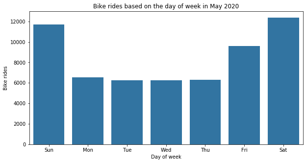

```python
# plotting the bike rides based on the start day of week
plt.figure(figsize=(10,5))
base_color=sb.color_palette()[0]
sb.countplot(data=df_clean, x='start_weekday_name', color=base_color)
plt.title('Bike rides based on the day of week in May 2020')
plt.xlabel('Day of week')
plt.ylabel('Bike rides');
```

#### Question: How does rides of member differ from that of customers?

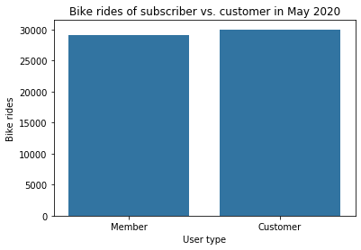

```python
# plotting the bike rides of user types
base_color=sb.color_palette()[0]
sb.countplot(data=df_clean, x='member_casual', color=base_color)
plt.title('Bike rides of subscriber vs. customer in May 2020')
plt.xlabel('User type')
plt.ylabel('Bike rides')
plt.xticks([0, 1], ['Member', 'Customer']);
```

Based on the above bar chart, there are slightly more customers renting the bikes that members in May 2020.

#### Question: How does the usage of ebike differ from that of docked-bikes?

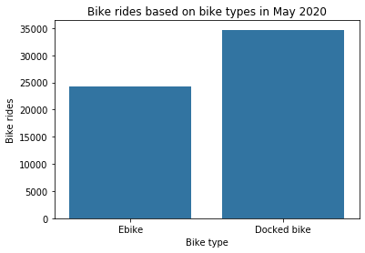

```python
# plotting the bike rides of different bike types
base_color=sb.color_palette()[0]
sb.countplot(data=df_clean, x='rideable_type', color=base_color)
plt.title('Bike rides based on bike types in May 2020')
plt.xlabel('Bike type')
plt.ylabel('Bike rides')
plt.xticks([0 ,1], ['Ebike', 'Docked bike']);
```

Since the bike types is qualitative variable, so bar chart is chosen to visualize the data. Based on it, more people chose to rent docked bikes than electric bikes

#### Question: How long do riders usually rent the bike?

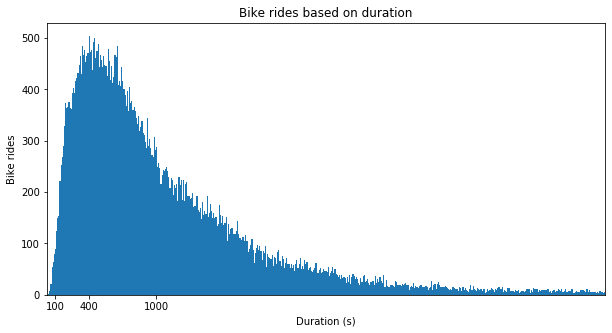

```python
# Bike rides based on duration
plt.figure(figsize=(10,5))
bin_edges = np.arange(0, 6000, 10)
plt.hist(data = df_clean, x = 'duration', bins = bin_edges)
plt.title('Bike rides based on duration')
plt.xlabel('Duration (s)')
plt.ylabel('Bike rides')
tick_loc=[100, 400, 1000]
plt.xticks(tick_loc, tick_loc)
plt.xlim(30, 5000)
plt.show();
```

#### How does the rides differ across time of a day?

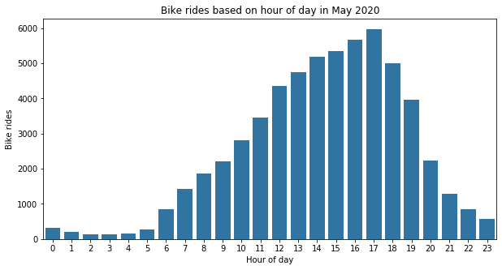

```python
# plotting the bike rides based on start hour
plt.figure(figsize=(10,5))
base_color=sb.color_palette()[0]
sb.countplot(data=df_clean, x='start_hour', color=base_color)
plt.title('Bike rides based on hour of day in May 2020')
plt.xlabel('Hour of day')
plt.ylabel('Bike rides');
```

#### Question: How does the rent of bikes differ across different stations?

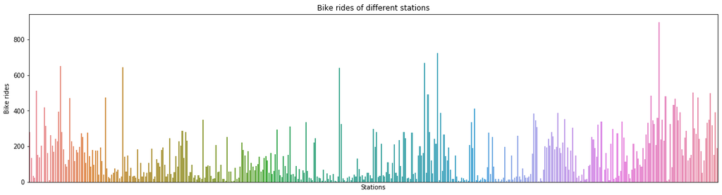

```python
# plot the bike rides for different stations
plt.figure(figsize=(20,5))
sb.countplot(data=df_clean, x='start_station_id')
plt.xlabel('Stations')
plt.ylabel('Bike rides')
plt.tick_params(axis='x',bottom=False, labelbottom=False)
plt.title('Bike rides of different stations');
```

```python
df_clean.start_station_id.nunique()
```

```
429
```

#### Findings of univariate exploration

I noticed there are negative duration when plotting the histogram of duration. The duration indicates the period of time a bike is rent so it should be positive. So I went back to the cleaning step to remove rows where duration is negative. Besides, the initial unit of duration was minute. However, I noticed that most of the distribution are narrowed to a single bar in histogram. So I went back to cleaning phase and changed the unit to seconds.

## Bivariate Exploration

#### Question: how do the numeric variables correlate with each other? Let's use the scatter plot to depict it

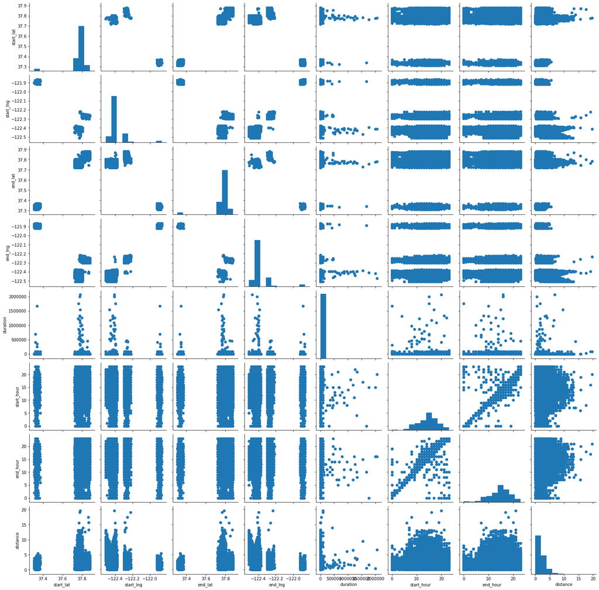

```python
numeric_cols = ['start_lat', 'start_lng', 'end_lat', 'end_lng', 'duration', 'start_hour', 'end_hour', 'distance']
g=sb.PairGrid(data=df_clean, vars=numeric_cols)
g=g.map_offdiag(plt.scatter)
g.map_diag(plt.hist)
```

Since all the variables are numeric ones, so the scatter plot is chosen to plot the data off the diagnol while the ones on the diagnol is plot by histograms. Among the numeric variables, start hour and end hour has relatively linear relationship excluding some outliers.

#### Question: how do the numeric variables correlate with each other? Let's use the heatmap to depict it

```python
sample=np.random.choice(df_clean.shape[0], 500, replace=False)
df_clean_sub = df_clean.iloc[sample]
```

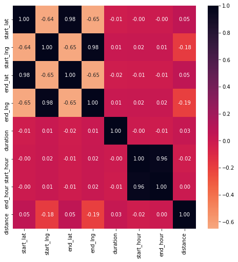

```python
numeric_cols = ['start_lat', 'start_lng', 'end_lat', 'end_lng', 'duration', 'start_hour', 'end_hour', 'distance']
plt.figure(figsize=[8,8])
sb.heatmap(df_clean[numeric_cols].corr(),cmap='rocket_r', annot=True, fmt='.2f', center=0);
```

Since all the variables are numeric ones, so heatmap is chosen to indicate their relationships. This headmap indicates that there are strong relationship between start latitude, start longitude, end latitude and end longitude. Besides, the hour to start riding and the hour to end riding also has a strong relationship.

#### Question: How does the duration of ebikes differ from that of docked bikes?

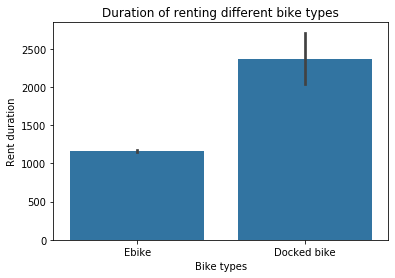

```python
sb.barplot(data=df_clean, x='rideable_type', y='duration', color=base_color)
plt.xlabel('Bike types')
plt.ylabel('Rent duration')
plt.title('Duration of renting different bike types')
plt.xticks([0 ,1], ['Ebike', 'Docked bike']);
```

Since the rideable_type is categorical data, so bar chart is chosent to plot the data. Based on the above plot, the mean duration of renting electric bike is almost half of that for docked bikes.

#### Question: How do members and customers act for different day of week?

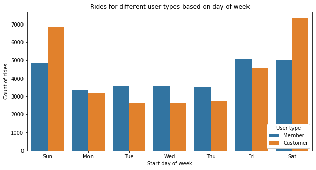

```python
# plotting ride counts of different user type based on the start day of week
plt.figure(figsize=[10,5])
sb.countplot(data=df_clean, x='start_weekday_name',hue='member_casual')
plt.legend(['Member', 'Customer'], title='User type', loc='lower right', framealpha=1) # set legend at lower right with no transparency
plt.xlabel('Start day of week')
plt.ylabel('Count of rides')
plt.title('Rides for different user types based on day of week');
```

Here is the point plot showing the same data as the bar chart above

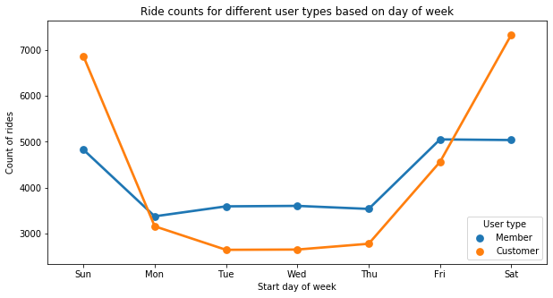

```python
plt.figure(figsize=[10,5])

# create a new dataframe with three columns: start weekday name, user type, and total ride counts
df_clean_start_weekday_sub = df_clean.groupby(['start_weekday_name', 'member_casual']).size().reset_index(name='total_counts')

# plotting, encode the user type as the third variable using colors
ax = sb.pointplot(data=df_clean_start_weekday_sub, x='start_weekday_name', y='total_counts', hue='member_casual')
handles, labels = ax.get_legend_handles_labels()
plt.legend(handles, ['Member','Customer'],loc="lower right", title='User type');
plt.xlabel('Start day of week')
plt.ylabel('Count of rides')
plt.title('Ride counts for different user types based on day of week');
```

Since day of week is categorical data, so the point plot and bar chart is used to plot the data. Besides, the user type is also a categorical data, so color is used to encode the data. The above bar chart and point chart indicate there are more rides during weekend than weekdays for both members and customers. The total rides of members is more than that of customers during weekdays but less than that during weekends.

#### Question: How many riders use the service across the time?

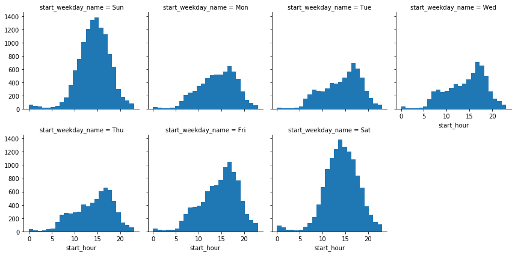

```python
# Faceting start days of week: distribution of ride count based on start hour
g=sb.FacetGrid(data=df_clean, col='start_weekday_name', col_wrap=4)
g.map(plt.hist, 'start_hour', bins=24);
```

Through different facets of start day, we can see that the peak of rides on weekdays is 17 o'clock while it's before 15 o'clock on weekends.

#### Question: How many members and customers use the service at different time of a day?

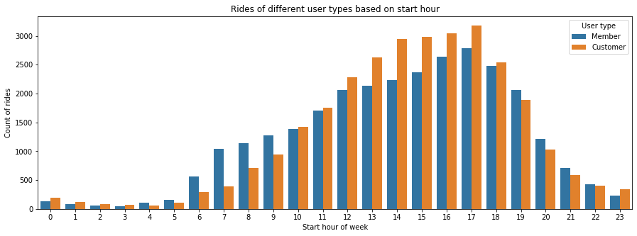

```python
# plotting ride counts of different user type based on the start day of week
plt.figure(figsize=[15,5])
sb.countplot(data=df_clean, x='start_hour',hue='member_casual')
plt.xlabel('Start hour of week')
plt.ylabel('Count of rides')
plt.title('Rides of different user types based on start hour')
plt.legend(['Member','Customer'], title='User type');
```

#### Question: How many riders choose ebikes and docked bikes respectively for each day of week?

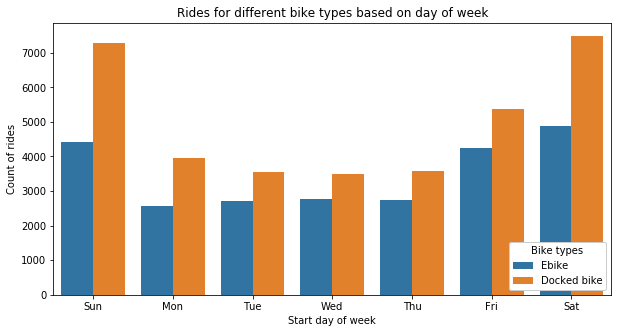

```python
# plotting ride counts of different user type based on the start day of week
plt.figure(figsize=[10,5])
sb.countplot(data=df_clean, x='start_weekday_name',hue='rideable_type')
plt.legend(['Ebike', 'Docked bike'], title='Bike types', loc='lower right', framealpha=1) # set legend at lower right with no transparency
plt.xlabel('Start day of week')
plt.ylabel('Count of rides')
plt.title('Rides for different bike types based on day of week');
```

The above plot indicates users ride more on weekends than weekdays for both electric bikes and docked bikes. Besides, the total amount of electric bike users are distributed equally from Monday to Thursday.

#### Question: How many riders choose ebikes and docked bikes respectively for each hour of a day?

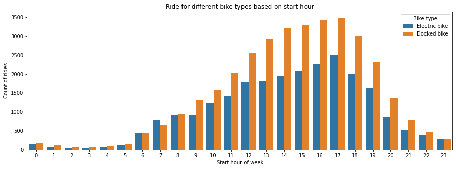

```python
# plotting ride counts of different user type based on the start day of week
plt.figure(figsize=[15,5])
sb.countplot(data=df_clean, x='start_hour',hue='rideable_type')
plt.xlabel('Start hour of week')
plt.ylabel('Count of rides')
plt.title('Ride for different bike types based on start hour')
plt.legend(['Electric bike','Docked bike'], title='Bike type');
```

The above plot indicates most users ride both electric and docked bikes at 17 o'clock and least at around 3 o'clock.

#### Question: How do duration and distance correlate to each other?

```python
# remove some outliers and create a new dataframe with duration less than 5000s and distance less than 12km
df_clean_common = df_clean[df_clean['distance'] < 12]
df_clean_common = df_clean_common[df_clean_common['duration'] < 3000]
```

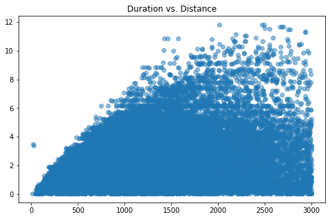

```python
# plotting
plt.figure(figsize=(8,5))
plt.scatter(data=df_clean_common, x='duration', y='distance', alpha=.5)
plt.title ('Duration vs. Distance');
```

The scatter plot above indicates the relationship of duration and distance is not always linear. The straight edge on the left side of this plot indicates, for some users, the distance increases linearly as the duration increases. However, a large amount of dots indicates the duration may increase while the distance keeps small. This fact tells us the user may rent the bike for a period of time but not necessarily always use it during this time.

#### Findings of bivariate exploration

The average duration of renting a ebike is less than that of a docked-bike. There are less users using both types of bikes during weekdays than weekends. Besides, 17 o'clock is the peak hour of using both types of bikes while 3 o'clock is the most silent time. It is interesting to notice the usage of ebikes is almost the same or over that of docked-bikes during 6 - 8 o'clock which is the time of start working for most people.

Moreover, the peak hour of using the service is 17 o'clock during weekdays but before 15 o'clock during weekends. Midnight, between 2 -4 o'clock is the most silent time for this service.

There is a strong linear relationship between the start hour and end hour of riding a bike which makes sense since the end hour is always after the start hour. The start position and end position also has a relationship. Besides, the duration and distance is related to each other linearly only for some riders but not necessarily for all riders.

## Multivariate Exploration

#### Question: Is there any difference of riding duration and distance between ebikes and docked bikes?

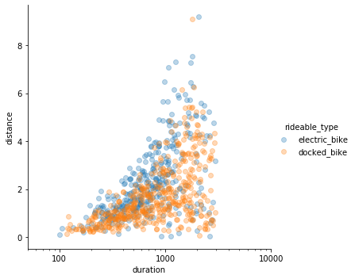

```python
# get 1000 sample data
sample = np.random.choice(df_clean_common.shape[0], 800, replace=False)
# create a sub-dataframe with the sample
df_clean_sub = df_clean_common.iloc[sample]

# plotting duration vs. distance for different bike types
g=sb.FacetGrid(data=df_clean_sub, hue='rideable_type', height=5)
g.map(plt.scatter, 'duration', 'distance', alpha=.3)
g.set(xscale='log') # get log of duration
x_ticks=[100, 1000, 10000]
plt.xlim(50, 10000)
g.set(xticks=x_ticks, xticklabels=x_ticks)
g.add_legend();
```

Since both duration and distance are numeric variables, so scatter plot is selected to plot the data. Besides, bike types is qualitative data, so color is used to encode it. The plot above indicates riders renting electric bikes generally ride longer distance than docked bikes for the same period of time. But it's not always the case since some riders may ride longer distance with docked-bikes.

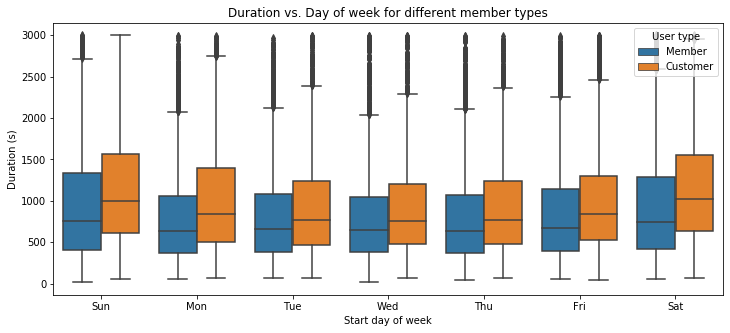

```python
plt.figure(figsize=(12, 5))
# use the dataframe with most outliers removed to plot
#relationship between day of week and duration for different member types
ax = sb.boxplot(data=df_clean_common, x='start_weekday_name', y='duration', hue='member_casual')
plt.xlabel('Start day of week')
plt.ylabel('Duration (s)')
plt.title('Duration vs. Day of week for different member types')
handles, labels = ax.get_legend_handles_labels()
plt.legend(handles, ['Member','Customer'],loc="upper right", title='User type');
```

The above plot indicates that the average duration of rides for members is relatively stable during weekdays but slightly increases during weekends. The average duration of rides for customers is less during weekdays than weekends.

#### Findings of multivariate exploration

Compared to that of customers, the average riding duration varies less for members everyday. Generally speaking, the average riding duration is less for members than that of customers on both weekdays and weekends. Besides, riders with ebikes generally tend to travel farer away during the same period of time. But renting an ebike does not always lead a rider to travel farer.